# Inferring the force of infection from sero-surveys

## Packages and general parameters

The needed packages:

```r
library(MASS)
library(magrittr)
library(stringr)
library(tidyr)
library(purrr)
library(dplyr) # safer to load it last
```

Defining some colors for the plots:

```r
blue <- "#377eb8"
red <- "#e41a1c"
green <- "#4daf4a"
pink <- adjustcolor(red, .1)
lightgreen <- adjustcolor(green, .1)
```

## Data and explorative visualization

Loading the data:

```r
serosurvey <- "Ecomore2-serosurvey-fileforMC.dta" %>%
  foreign::read.dta() %>%
  as_tibble()
```

Selecting `Age` and `den_delta` variables:

```r
sero_age <- serosurvey %>%
  select(Age, den_delta) %>%
  mutate(den_delta = den_delta == "positif")
```

Calculating seroprevalence with confidence intervals by age classes:

```r
seroprev <- function(data, breaks) {
  data %>%
    mutate(age_cat = cut(Age, breaks, include.lowest = TRUE)) %>%
    group_by(age_cat) %>%
    summarise(x = sum(den_delta),
              n = n()) %>%
    mutate(prop = map2(x, n, prop.test),
           estm = map_dbl(prop, function(x) x$estimate),
           conf = map(prop, function(x) x$conf),
           lwer = map_dbl(conf, first),
           uppr = map_dbl(conf, last)) %>%
    select(-prop, -conf) %>%
    mutate(age_cat = as.character(age_cat) %>%
                       str_remove("\\[") %>%
                       str_remove("\\(") %>%
                       str_remove("\\]")) %>%
    separate(age_cat, c("min", "max"), ",") %>%
    mutate_at(vars(min, max), as.numeric) %>%
    mutate(middle = select(., min, max) %>%
                      apply(1, mean))
}
```

Let’s try it with as equal as possible numbers of data points per age category:

```r
seroprev(sero_age, quantile(sero_age$Age, seq(0, 1, le = 9)))
```

```
## # A tibble: 8 x 8
##        min   max     x     n   estm   lwer   uppr middle
##      <dbl> <dbl> <int> <int>  <dbl>  <dbl>  <dbl>  <dbl>
## 1  0.00274  6.68     5   165 0.0303 0.0112 0.0730   3.34
## 2  6.68    18       15   168 0.0893 0.0526 0.146   12.3
## 3 18       23.7     33   159 0.208  0.149  0.281   20.8
## 4 23.7     29.2     32   164 0.195  0.139  0.266   26.4
## 5 29.2     36       31   164 0.189  0.134  0.259   32.6
## 6 36       44       53   165 0.321  0.252  0.399   40
## 7 44       55       58   163 0.356  0.284  0.435   49.5
## 8 55       88       59   164 0.360  0.287  0.439   71.5
```

A function that plots the seroprevalence estimates:

```r
plot_seroprev <- function(estimates, xlim = c(0, 90), ylim = 0:1, col = blue) {
  with(estimates, {
    plot(middle, estm, xlab = "age (years)", ylab = "seroprevalence",
         xlim = xlim, ylim = ylim, col = col)
    arrows(middle, lwer, middle, uppr, .05, 90, 3, col)
  })
}
```

Let’s plot these estimates:

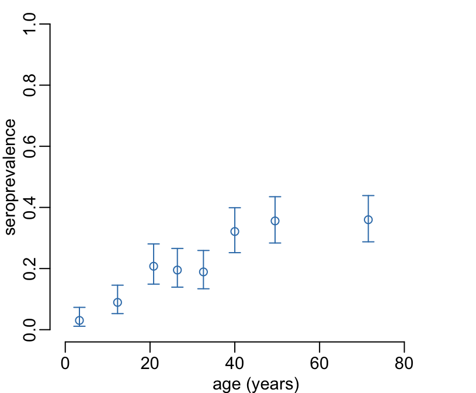

```r
sero_age %>%
  seroprev(quantile(sero_age$Age, seq(0, 1, le = 9))) %>%
  plot_seroprev()
```

Same thing with twice as many age classes:

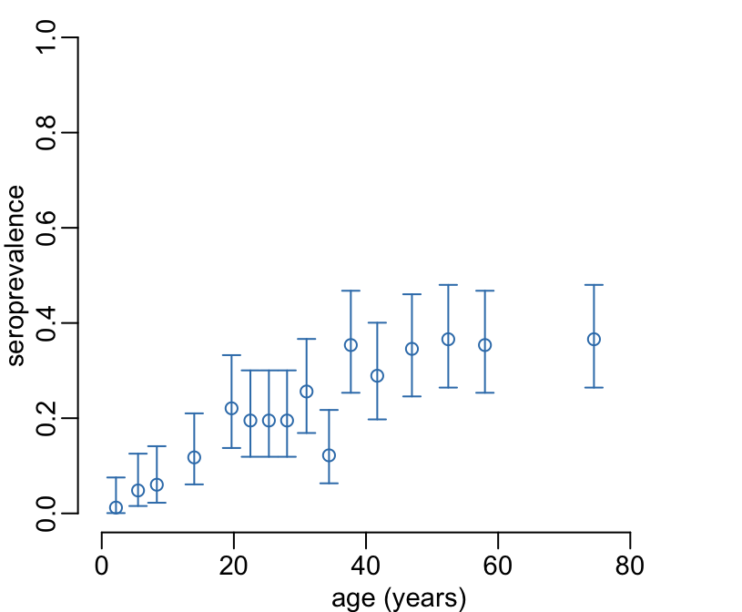

```r
sero_age %>%
  seroprev(quantile(sero_age$Age, seq(0, 1, le = 17))) %>%
  plot_seroprev()
```

Or with predefined age classes:

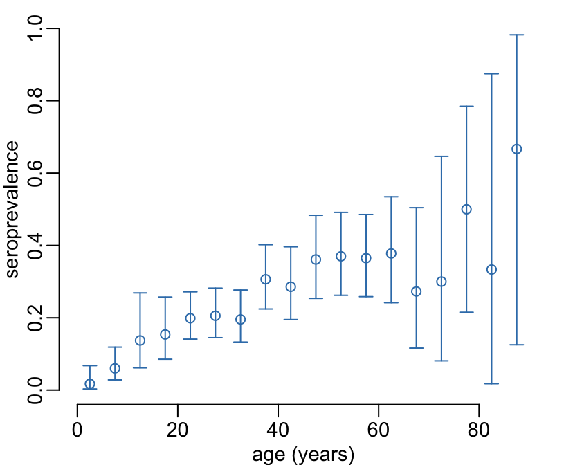

```r
sero_age %>%
  seroprev(seq(0, 90, 5)) %>%
  plot_seroprev()
```

Another one:

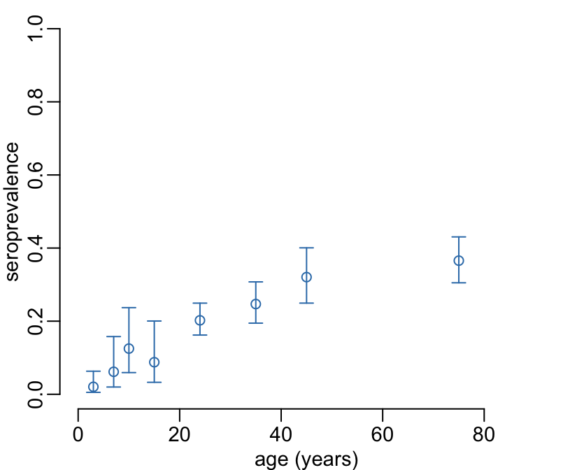

```r
sero_age %>%
  seroprev(c(0, 6, 8, 12, 18, 30, 40, 50, 100)) %>%
  plot_seroprev()
```

## Inferring the force of infection from a polynomial logistic model

Let’s model the force of infection using a binomial model:

```r
full_model <- glm(den_delta ~ Age + I(Age^2) + I(Age^3) + I(Age^4) + I(Age^5) + I(Age^6) +
                    I(Age^7) + I(Age^8) + I(Age^9) + I(Age^10) + I(Age^11) + I(Age^12) + I(Age^13) +
                    I(Age^14) + I(Age^15) + I(Age^16) + I(Age^17), binomial, sero_age)
```

Sequential likelihood ratio tests:

```r
anova(full_model, test = "LRT")
```

```
## Analysis of Deviance Table
##
## Model: binomial, link: logit
##
## Response: den_delta
##
## Terms added sequentially (first to last)
##
##
##           Df Deviance Resid. Df Resid. Dev  Pr(>Chi)
## NULL                       1311     1375.9
## Age        1   88.340      1310     1287.5 < 2.2e-16 ***
## I(Age^2)   1   13.469      1309     1274.1 0.0002425 ***
## I(Age^3)   1    3.314      1308     1270.8 0.0686765 .
## I(Age^4)   1    0.344      1307     1270.4 0.5577442
## I(Age^5)   1    4.698      1306     1265.7 0.0302030 *
## I(Age^6)   1    0.607      1305     1265.1 0.4359173
## I(Age^7)   1    0.098      1304     1265.0 0.7546725
## I(Age^8)   1    0.417      1303     1264.6 0.5184378
## I(Age^9)   1    1.323      1302     1263.3 0.2500178
## I(Age^10)  1    0.387      1301     1262.9 0.5336726
## I(Age^11)  1    0.367      1300     1262.5 0.5447094
## I(Age^12)  1    1.279      1299     1261.2 0.2580801
## I(Age^13)  1    0.189      1298     1261.1 0.6637457
## I(Age^14)  1    0.582      1297     1260.5 0.4456581
## I(Age^15)  1    1.680      1296     1258.8 0.1948643
## I(Age^16)  1    0.109      1295     1258.7 0.7418571
## I(Age^17)  1    0.316      1294     1258.4 0.5742052
## ---
## Signif. codes:  0 '***' 0.001 '**' 0.01 '*' 0.05 '.' 0.1 ' ' 1
```

Let’s see whether the model with degree 5 is better than the model with degree 2:

```r
mod2 <- glm(den_delta ~ Age + I(Age^2), binomial, sero_age)
mod5 <- update(mod2, . ~ . + I(Age^3) + I(Age^4) + I(Age^5))
anova(mod2, mod5, test = "LRT")
```

```
## Analysis of Deviance Table
##
## Model 1: den_delta ~ Age + I(Age^2)
## Model 2: den_delta ~ Age + I(Age^2) + I(Age^3) + I(Age^4) + I(Age^5)
##   Resid. Df Resid. Dev Df Deviance Pr(>Chi)
## 1      1309     1274.1
## 2      1306     1265.7  3   8.3557   0.0392 *
## ---
## Signif. codes:  0 '***' 0.001 '**' 0.01 '*' 0.05 '.' 0.1 ' ' 1
```

`mod5` seems the best. The following function computes the predictions with confidence interval:

```r
predict2 <- function(x, newdata, ci = .95) {
  ci <- (1 - ci) / 2
  linkinv <- family(x)$linkinv
  predict(x, newdata, se.fit = TRUE) %>%
    data.frame() %>%
    mutate(lower = linkinv(fit + qt(ci, Inf) * se.fit),
           upper = linkinv(fit + qt(1 - ci, Inf) * se.fit),
           fit   = linkinv(fit)) %>%
    select(-residual.scale, -se.fit)
}
```

Let’s see what it looks like compared to the age classes estimates:

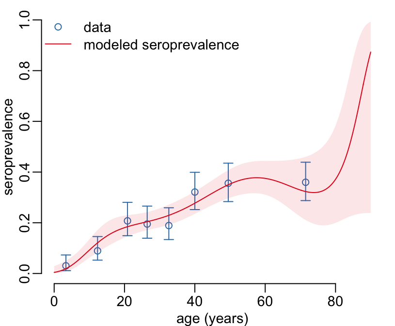

```r
sero_age %>%
  seroprev(quantile(sero_age$Age, seq(0, 1, le = 9))) %>%
  plot_seroprev()
age_val <- seq(0, 90, le = 512)
mod5 %>%
  predict2(data.frame(Age = age_val)) %>%
  with({
    polygon(c(age_val, rev(age_val)), c(lower, rev(upper)), col = pink, border = NA)
    lines(age_val, fit, col = red)})
legend("topleft", legend = c("data", "modeled seroprevalence"),
       bty = "n", col = c(blue, red), pch = c(1, NA), lty = c(NA, 1))
```

Note that the polynomial logistic model performs poorly at edges, especially when there is too few data (right edge here). The following functions derives the force of infection from the logistic regression coefficients’ estimates following the following equation:

$$\lambda(a) = \eta'(a)\frac{e^{\eta(a)}}{1 + e^{\eta(a)}}$$
where $a$ is age, $\lambda$ is the force of infection, $\eta$ is the linear predictor of the logistic model and $\eta'$ is the first derivative of this linear predictor, respective to $a$:

```r
foi <- function(Age, coef) {
  f <- function(x) x[x >= 0]
  degree <- seq_along(coef) - 1
  eta <- degree %>%
    map(~ Age^.x) %>%
    map2(coef, multiply_by) %>%
    as.data.frame() %>%
    rowSums()
  eta_prime <- f(degree - 1) %>%
    map(~ Age^.x) %>%
    map2(coef[-1], multiply_by) %>%
    as.data.frame() %>%
    rowSums()
  eta_prime * exp(eta) / (1 + exp(eta))
}
```

Let’s try it:

```r
foi_est <- foi(age_val, coef(mod5))
```

Let’s compute the confidence interval (takes about 20’’):

```r
foi_ci <- mvrnorm(1e4, coef(mod5), vcov(mod5)) %>%
  t() %>%
  as.data.frame() %>%
  map(foi, Age = age_val) %>%
  as.data.frame() %>%
  apply(1, quantile, c(.025, .975)) %>%
  t() %>%
  as.data.frame() %>%
  setNames(c("lower", "upper"))
```

Let’s plot it:

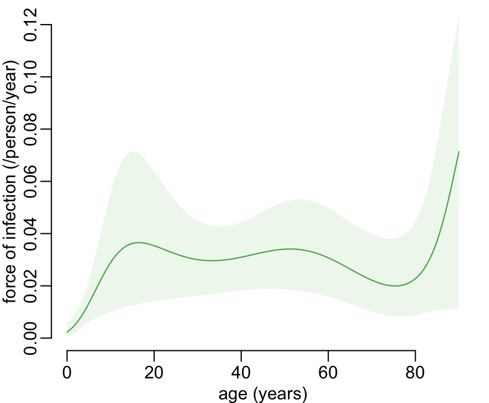

```r
plot(age_val, foi(age_val, coef(mod5)), ylim = c(0, .12), type = "n",
     xlab = "age (years)", ylab = "force of infection (/person/year)")
with(foi_ci, polygon(c(age_val, rev(age_val)), c(lower, rev(upper)), border = NA, col = lightgreen))
lines(age_val, foi_est, col = green)
```

The force of infection is the rate at which susceptible individuals aquired an infection. This figure thus suggests that children under 10 are less exposed than adults. The following function plot the data, the modeled seroprevalence and the modeled force of infection on the same figure:

```r
plot_prev_foi <- function(mod) {
  opar <- par(plt = c(.105, .895, .13, .97))
  sero_age %>%
    seroprev(quantile(sero_age$Age, seq(0, 1, le = 9))) %>%
    plot_seroprev()
  mod %>%
    predict2(data.frame(Age = age_val)) %>%
    with({
      polygon(c(age_val, rev(age_val)), c(lower, rev(upper)), col = pink, border = NA)
      lines(age_val, fit, col = red)})
  legend("topleft", legend = c("data", "modeled seroprevalence", "modeled force of infection"),
         bty = "n", col = c(blue, red, green), pch = c(1, NA, NA), lty = c(NA, 1, 1))
  par(plt = c(.105, .895, .13, .45), new = TRUE)
  plot(age_val, foi(age_val, coef(mod)), ylim = c(0, .12), type = "n", axes = FALSE, ann = FALSE)
  with(foi_ci, polygon(c(age_val, rev(age_val)), c(lower, rev(upper)), border = NA, col = lightgreen))
  lines(age_val, foi_est, col = green)
  axis(4)
  mtext("foi (/person/year)", 4, 1.5)
  par(opar)
}
```

Let’s try it:

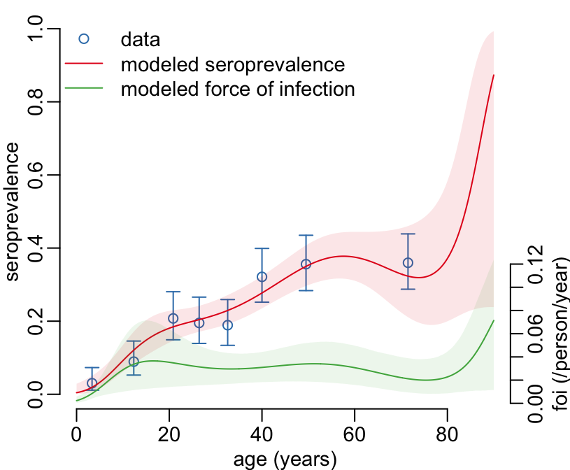

```r
plot_prev_foi(mod5)
```

### Forcing a 0 intercept

Let’s do the same, this time forcing an intercept equal to zero:

```r
full_model <- update(full_model, . ~ . -1)
```

Let’s look at the sequential likelihood ratio tests:

```r
anova(full_model, test = "LRT")
```

```
## Analysis of Deviance Table
##
## Model: binomial, link: logit
##
## Response: den_delta
##
## Terms added sequentially (first to last)
##
##
##           Df Deviance Resid. Df Resid. Dev  Pr(>Chi)
## NULL                       1312     1818.8
## Age        1  191.660      1311     1627.2 < 2.2e-16 ***
## I(Age^2)   1  142.063      1310     1485.1 < 2.2e-16 ***
## I(Age^3)   1   80.753      1309     1404.3 < 2.2e-16 ***
## I(Age^4)   1   64.251      1308     1340.1 1.095e-15 ***
## I(Age^5)   1   23.787      1307     1316.3 1.076e-06 ***
## I(Age^6)   1   24.184      1306     1292.1 8.757e-07 ***
## I(Age^7)   1   15.168      1305     1277.0 9.835e-05 ***
## I(Age^8)   1    7.622      1304     1269.3  0.005767 **
## I(Age^9)   1    0.261      1303     1269.1  0.609153
## I(Age^10)  1    3.823      1302     1265.2  0.050541 .
## I(Age^11)  1    0.077      1301     1265.2  0.781909
## I(Age^12)  1    2.762      1300     1262.4  0.096508 .
## I(Age^13)  1    0.037      1299     1262.4  0.847209
## I(Age^14)  1    0.857      1298     1261.5  0.354622
## I(Age^15)  1    1.369      1297     1260.1  0.242057
## I(Age^16)  1    0.030      1296     1260.1  0.861687
## I(Age^17)  1    0.073      1295     1260.0  0.787548
## ---
## Signif. codes:  0 '***' 0.001 '**' 0.01 '*' 0.05 '.' 0.1 ' ' 1
```

Best candidate models:

```r
mod12 <- update(full_model, . ~ . -I(Age^13) - I(Age^14) - I(Age^15) - I(Age^16) - I(Age^17))
mod10 <- update(mod12, . ~ . -I(Age^11) - I(Age^12))
mod8 <- update(mod10, . ~ . -I(Age^9) - I(Age^10))
```

Let’s compare `mod10` and `mod12` to `mod8`:

```r
anova(mod8, mod10, test = "LRT")
```

```
## Analysis of Deviance Table
##
## Model 1: den_delta ~ Age + I(Age^2) + I(Age^3) + I(Age^4) + I(Age^5) +
##     I(Age^6) + I(Age^7) + I(Age^8) - 1
## Model 2: den_delta ~ Age + I(Age^2) + I(Age^3) + I(Age^4) + I(Age^5) +
##     I(Age^6) + I(Age^7) + I(Age^8) + I(Age^9) + I(Age^10) - 1
##   Resid. Df Resid. Dev Df Deviance Pr(>Chi)
## 1      1304     1269.3
## 2      1302     1265.2  2   4.0848   0.1297
```

```r
anova(mod8, mod12, test = "LRT")
```

```
## Analysis of Deviance Table
##
## Model 1: den_delta ~ Age + I(Age^2) + I(Age^3) + I(Age^4) + I(Age^5) +
##     I(Age^6) + I(Age^7) + I(Age^8) - 1
## Model 2: den_delta ~ Age + I(Age^2) + I(Age^3) + I(Age^4) + I(Age^5) +
##     I(Age^6) + I(Age^7) + I(Age^8) + I(Age^9) + I(Age^10) + I(Age^11) +
##     I(Age^12) - 1
##   Resid. Df Resid. Dev Df Deviance Pr(>Chi)
## 1      1304     1269.3
## 2      1300     1262.4  4   6.9238     0.14
```

Best model seems to be `mod8`. Let’s plot it:

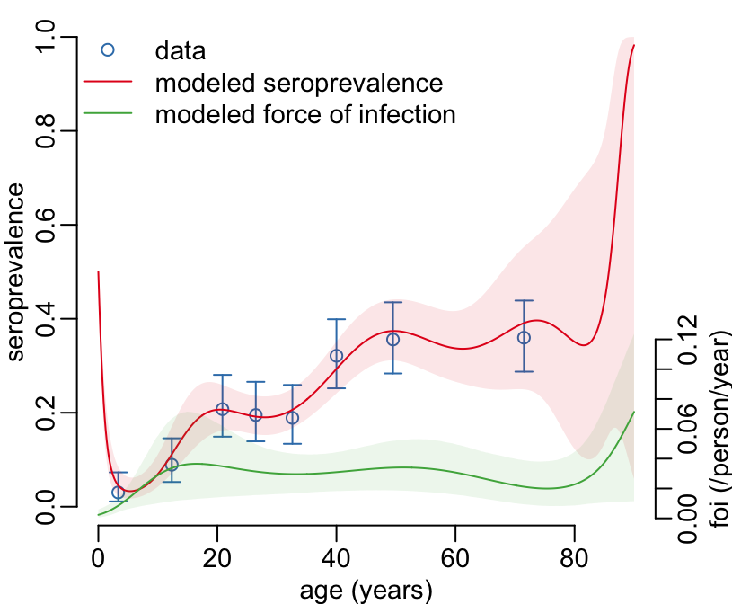

```r
plot_prev_foi(mod8)
```